[figure not shown]

# PYT201 - Analysis and Data Wrangling

## Week 3

#### 05/06/2021

## Introduction

- Week 1 - Introduction to Data Analysis
  - Functional Programming
  - NumPy
- Week 2 - Intro to APIs
- **(This week) Week 3 - Exploring and Manipulating Data with Pandas**
  - **Exploratory Data Analysis (EDA)**
  - **Pandas Series and Data Frames**
  - **merge, sort, group, filter ...**
- Week 4 - Gitlab & Git
- Week 5 - Advanced Pandas and Intro to Visualization
  - Data Analysis using an actual project as an example.
  - Basics of Data Visualization
  - Matplotlib
- Week 6 - Analysis Model Visualization Part II
  - Seaborn
  - Bokeh
- Week 7 - Student Demos

[figure not shown]

# Pandas

### What is Pandas?

**pandas** is a fast, powerful, flexible and easy to use open source data analysis and manipulation tool, built on top of the Python programming language.

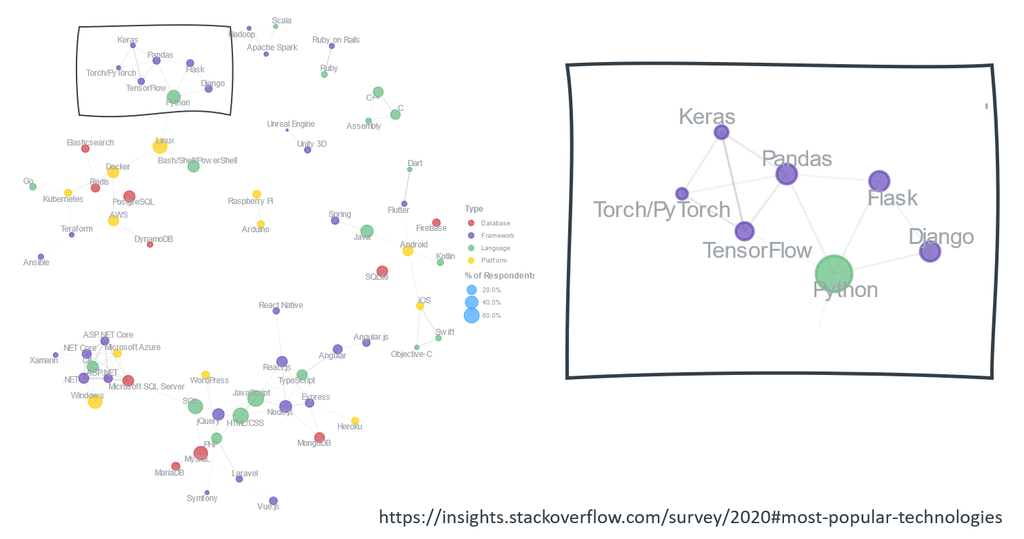

**Pandas is not a relational database library, but instead a “data frame” library.** You can think of a data frame as being essentially like a 2D array, except that entires in the data frame can be any type of Python object (and have mixed types within the array), and the rows/columns can have “labels” instead of just integer indices like in a standard array. (https://www.datasciencecourse.org/notes/relational_data/#:~:text=These%20are%20especially%20simple%20libraries,client%2Fserver%20architecture%20of%20virtually)

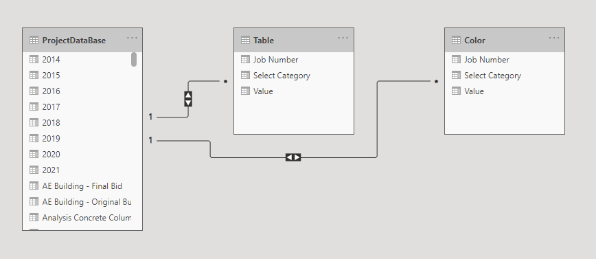

**What can you do with pandas?**

- Indexing, manipulating, renaming, sorting, merging data frames
- Update, Add, Delete columns from a data frame
- Handle missing data or NANs
- Plot data (basic)

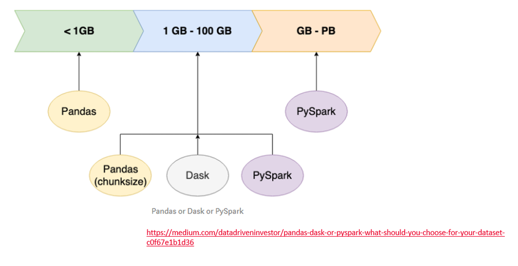

### Why Pandas?

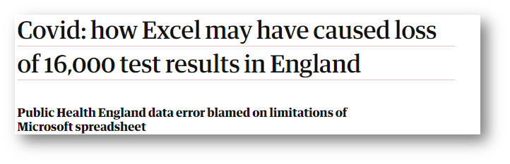

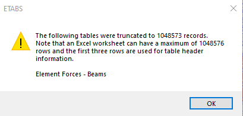